# Fair-Policing Assignment #3

#### Data Generation Process

Originally, the data was collected through the San Diego Police with the pre-2018 years consisting of one csv and the post-2018 consisting of many RIPA csv's that one had to merge to create a dataframe that consists of the above columns. From there, once the data was collected, aggregations to find the stop-rates and post-stop outcomes had to occur. In order to find the stop-rates, I first had to find the total population living in San Diego and more specifically the service areas in the city. To do this, one has to spatially join the census population dataset to the police stops dataset, which I did through ArcGIS because once one plots the census population dataset as centroids on top of the police beats split by service area, the software is able to join spatially based of the coordinates of the one service area to many centroids join. One thing to take note of was the when joining the two dataframes, I chose to count the centroids fully inside the service area boundaries as the centroids were small enough that only ~3% of the centroids intersected between multiple service areas.

### EDA

```
Text(0.5,1,'Amount of Drivers Stopped Across the Driver Age')
```

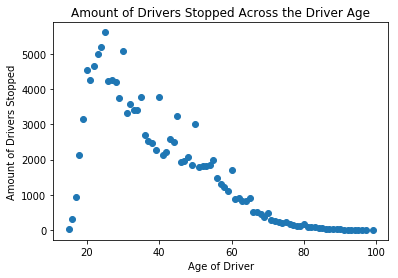

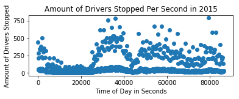

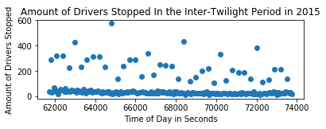

For the chart above, I wanted to compare the stop rates throught the year 2015 in time of day seconds. From the chart on the top, we can see peaks during certain times of day, like >750 drivers being stopped near 8 am (37,000 seconds), in comparison to the peaks at around 5 pm (58,000 second) and 10 pm (79,000 seconds). To look more closely at the trends, I decided to graph the stops in 2015 that occurred during the inter-twilight period. We can see a spike in the data every 1000 seconds (or ~30 minute) which shows that officers often most likely round the police stopping of a driver time to the nearest 30 minute or 1 hour.

### Reliability of Data

#### Precision

Another example of where data is not precise is when the post2018 dataset was more exact in allocating gender to the stopped subjects whereas pre2018 only had 'M' for Males or 'F' for Females or 'X' for Unknown for those they had no idea about.

|  | subject_race |
| --- | --- |
| W | 196665 |
| H | 141695 |
| B | 51754 |
| O | 35395 |
| A | 21695 |
| F | 6213 |
| V | 3348 |
| C | 2450 |
| I | 2280 |
| X | 713 |
| K | 649 |
| J | 541 |
| P | 514 |
| Z | 349 |
| L | 316 |
| S | 250 |
| D | 249 |
| G | 124 |
| U | 66 |

|  | subject_race |
| --- | --- |
| White | 103731 |
| Hispanic/Latino/a | 69465 |
| Black/African American | 46522 |
| Asian | 12189 |
| Middle Eastern or South Asian | 6796 |
| Pacific Islander | 2075 |
| Native American | 512 |

|  | Driver Race | Number Of Stops | Percentage of Stops |
| --- | --- | --- | --- |
| 0 | White | 300396 | 0.425585 |
| 1 | Hispanic/Latino/a | 211160 | 0.299160 |
| 2 | Black/African American | 98276 | 0.139232 |
| 3 | Other | 35395 | 0.050146 |
| 4 | Middle Eastern or South Asian | 31120 | 0.044089 |
| 5 | Asian | 25955 | 0.036772 |
| 6 | Pacific Islander | 3029 | 0.004291 |
| 7 | Native American | 512 | 0.000725 |

|  | subject_sex |
| --- | --- |
| M | 301139 |
| F | 163924 |
| X | 66 |

|  | subject_sex |
| --- | --- |
| 1 | 178441 |
| 2 | 62151 |
| 3 | 385 |
| 4 | 240 |
| 0 | 73 |

#### Missingness

From the nulls, one can assume that the driver had their property seized and had contraband found by the officers only after they had provided consent or had been searched.

```
Text(0,0.5,'Percentage of Nulls')
```

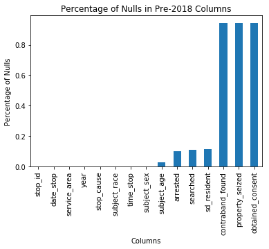

```
Text(0,0.5,'Percentage of Nulls')
```

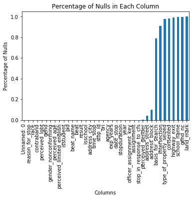

#### Accuracy

Another factor we had to look for in the reliability of the data was age. This is an example of data that is very hard to make accurate as although legal ages for drivers exist, this data consists of not only ages that are too young to be legal but ones that are too old to be alive. In order to create the anaylsis, I made the assumption that ages below 14 would not drive and neither would those ages greater than 120. From this assumption, I decided to coerce and grab the ages between 14 - 120 while dropping everything else. From the graph, we can see that the lines are thicker and longer near integers the end in 5's and 0's. This maybe because of officers perceiving age in the post2018 dataset (also has to do with precision when officers perceived age to be closer to 'bin ages').

Another example of accuracy is the race codes in the datasets. These are accurate because the officers had to bubble in the race codes so they were not misspelled or written with capitals or lower case letters.

The stop causes for pre2018 are inaccurate as there are many of the same meanings with different inputs such as 'NOTHING MARKED', 'NOT SPECIFIED', and 'NOT MARKED'. This in return makes the data harder and more inefficient to clean because you'd have to loop through all of the unique inputs and map it to one form.

|  | stop_cause |
| --- | --- |
| Moving Violation | 344856 |
| Equipment Violation | 114205 |
| Radio Call/Citizen Contact | 2181 |
| Muni, County, H&S Code | 1625 |
| Personal Knowledge/Informant | 1011 |
| No Cause Specified on a Card | 707 |
| Suspect Info (I.S., Bulletin, Log) | 644 |
| Personal Observ/Knowledge | 254 |
| UNI, &County, H&&S Code | 73 |
| MUNI, County, H&S Code | 55 |
| Other | 39 |
| &Moving Violation | 21 |
| Suspect Info | 19 |
| none listed | 6 |
| not marked | 4 |

```
Text(0.5,1,'Age of Drivers')
```

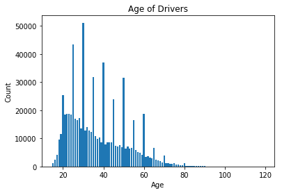

### Approach to Cleaning

In order to star cleaning the data, I first looked at the count of each driver race and used that to see which races would make a larger and more significant effect on the dataset.

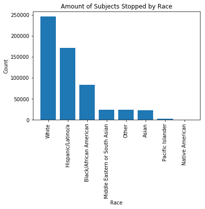

I also looked at the missingness of each column in the dataset and used the percent of missing data to aid me in taking either the imputation of the column or dropping the nulls. Analyzing patterns of missing data can aid in finding the explanation of how and why the missingness occurred and provide a little insight into what they mean for the dataset's reliability and its effect on the overall analysis. In this case, for many, the nulls actually meant that the driver was not stopped, searched, arrested and so on so I mapped the values to 0. I found that rather than having type 'object' columns, it was easier to map binary values like 0 and 1 so that the charting of the data would be easier.

## Stop Rates

In order to get the stop rates, census population data first had to get downloaded and joined to the police stops data because the true denominator is actually the amount of residents in San Diego in comparison to the amount of drivers stopped. To join these two datasets, I used ArcGIS to first plot the police census dataset by beat and then uploaded the census data, found the centorids of the population and used that to create boundaries. Once the centroids were done, I spatially joined mulitple centroids that were completely within service areas to one service area and found that those centroids who were intersecting srvice areas actually on consisted of <3% of the centroids.

|  | Population | Number of Stops | % of Stops/Population |
| --- | --- | --- | --- |
| 0.0 | 0.0 | NaN | NaN |
| 110.0 | 127318.0 | 42407.0 | 0.333079 |
| 120.0 | 89063.0 | 63901.0 | 0.717481 |
| 130.0 | NaN | 253.0 | NaN |
| 230.0 | 109952.0 | 28068.0 | 0.255275 |
| 240.0 | 108664.0 | 37281.0 | 0.343085 |
| 310.0 | 66967.0 | 55223.0 | 0.824630 |
| 320.0 | 74494.0 | 27935.0 | 0.374997 |
| 430.0 | 114663.0 | 28251.0 | 0.246383 |
| 440.0 | 50764.0 | 26681.0 | 0.525589 |
| 510.0 | 58180.0 | 34706.0 | 0.596528 |
| 520.0 | 40038.0 | 73791.0 | 1.843024 |
| 530.0 | 249.0 | 3600.0 | 14.457831 |
| 610.0 | 61442.0 | 38891.0 | 0.632971 |
| 620.0 | 70411.0 | 39262.0 | 0.557612 |
| 630.0 | NaN | 246.0 | NaN |
| 710.0 | 30695.0 | 42669.0 | 1.390096 |
| 720.0 | 73187.0 | 31341.0 | 0.428232 |
| 810.0 | 54563.0 | 24491.0 | 0.448857 |
| 820.0 | 55196.0 | 25772.0 | 0.466918 |
| 830.0 | 52521.0 | 25146.0 | 0.478780 |
| 840.0 | NaN | 37.0 | NaN |
| 930.0 | 69028.0 | 36046.0 | 0.522194 |

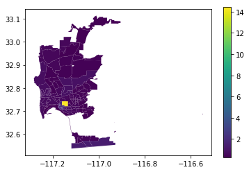

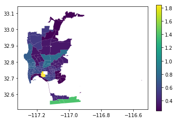

The table below shows that white drivers made up about 6% of stop rates in San Diego during 2015 in relation to the 20% of black drivers stopped. This is surprising becuase if you look at the overall population of San Diego there are around 769967 white driver residents as comapred to the significantly lower amount of black drivers (about 87949).

|  | 0 |
| --- | --- |
| Asian | 0.022432 |
| Black/African American | 0.202371 |
| Other | 0.279779 |
| Pacific Islander | 0.067127 |
| Total | 0.097371 |
| White | 0.059204 |

|  | 0 |
| --- | --- |
| Asian | 207944 |
| Black/African American | 87949 |
| Native American | 7696 |
| Other | 227931 |
| Pacific Islander | 5908 |
| Total | 1307395 |
| White | 769967 |

## Post-Stop Outcomes

Not surprisingly, when taking into account the post-stop outcomes by each race, we saw a siginificant increase in the amount of searches for black drivers in comparison to any other race where as the white drivers had the lowest serach rates.

| subject_race | Asian | Black/African American | Hispanic/Latino/a | Pacific Islander | White |
| --- | --- | --- | --- | --- | --- |
| arrested | 0.011022 | 0.017424 | 0.013064 | 0.016529 | 0.011126 |
| contraband_found | 0.002204 | 0.007018 | 0.003977 | 0.000000 | 0.002807 |
| property_seized | 0.002756 | 0.005969 | 0.006735 | 0.004132 | 0.002927 |
| searched | 0.034996 | 0.079858 | 0.050022 | 0.061983 | 0.025701 |
| subject_race | 3629.000000 | 12397.000000 | 34445.000000 | 242.000000 | 49881.000000 |

```
Text(0,0.5,'Mean Rates')
```

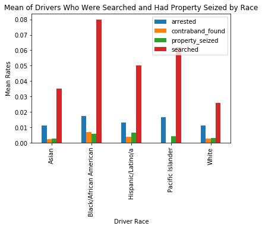

In order to look at post-stop outcomes more wholistically, I looked to see the rates of total searches, arrests, contraband found and property seized and found that there was in increas in all of these outcomes between 2017 and 2018. This is also when the new method of police reporting came into play with the RIPA datasets so it was not surprising as it was harder for police officers to not fill out these post 2017 reports.

| year | arrested | contraband_found | property_seized | searched |
| --- | --- | --- | --- | --- |
| 2014 | 0.014123 | 0.004245 | 0.005306 | 0.049541 |
| 2015 | 0.011662 | 0.003422 | 0.004245 | 0.037922 |
| 2016 | 0.012033 | 0.004677 | 0.005192 | 0.038544 |
| 2017 | 0.010289 | 0.004149 | 0.005348 | 0.043125 |
| 2018 | 0.153012 | 0.057266 | 0.019976 | 0.166971 |
| 2019 | 0.190029 | 0.073715 | 0.021238 | 0.219540 |

```
Text(0,0.5,'Percent of Post-Stop Outcomes')
```

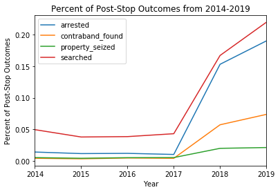

## Veil of Darkness

### Explanation

For this section, we will do a replication of the inter-twilight analysis that was done in the SDSU study. The Veil of Darkness method aims to use data that is unbiased in terms of stop decisions. This method relies on the idea that the officers who were stopping individuals based on their races and skin colors would not affect the effect of post stop outcomes as it takes into consideration the amount of daylight and darkness outside. According to the study, "The naive approach is just to compare whether daytime stops or nighttime stops have higher proportion of black drivers". To adjust for the differences in the time of the sun setting throughout the year, we use the inter-twilight period which aims to focus on stops that occur within 5:09 PM and 8:29 PM. Once this time period was aggregated, I webscraped sunset times for each day of each month that occured during this time period and mapped that service areas to the sunset times. From this, I was able to place drivers during the inter-twilight period as either being stopped in the light versus the dark (our train and test sets). From there a hypothesis of whether racial disparity truly exists was conducted and deduced that there was no significant difference in stop rates between Asian, Black and White drivers who were stopped in the light vs dark period of the inter-twilight period.

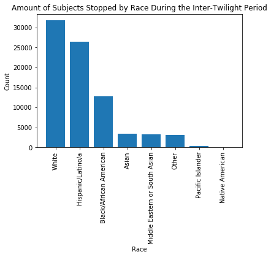

| subject_race | property_seized mean | property_seized sum | searched mean | searched sum | stop_id count | subject_age mean |
| --- | --- | --- | --- | --- | --- | --- |
| Asian | 0.083333 | 7.0 | 1.000000 | 55.0 | 372 | 41.500000 |
| Black/African American | 1.000000 | 33.0 | 1.000000 | 351.0 | 1576 | 57.500000 |
| Hispanic/Latino/a | 0.333333 | 39.0 | 1.000000 | 384.0 | 4260 | 60.000000 |
| Middle Eastern or South Asian | 0.062500 | 2.0 | 0.500000 | 17.0 | 313 | 41.971831 |
| Other | 0.076923 | 2.0 | 0.153846 | 6.0 | 369 | 41.000000 |
| Pacific Islander | 0.166667 | 3.0 | 1.000000 | 13.0 | 38 | 47.500000 |
| White | 1.000000 | 51.0 | 1.000000 | 386.0 | 3184 | 70.000000 |
| Native American | 0.666667 | 2.0 | 1.000000 | 3.0 | 13 | 65.000000 |

```
Text(0.5,0,'Race')
```

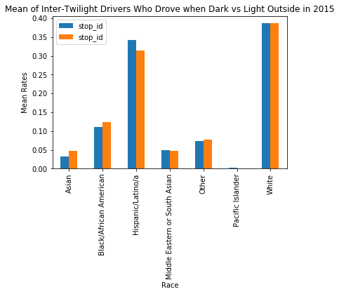

```
Ks_2sampResult(statistic=0.1428571428571429, pvalue=0.9999951796657175)
```

#### Shortcomings

The Veil of Darkness had many shortcomings with artificial light being the most significant. From the pvalue of 0.9, we can see that the KS sample hypothesis had no significance on the 'Light' and 'Dark' dubbed times of day. From the bar chart, we can also see that there were similar averages of stop rates done during the inter-twilight period in times before and times after the sunset. This data and these charts showed that no statistically significant difference existed in the 2015 stop patterns of black and white drivers.

```
Text(0.5,0,'Race')
```

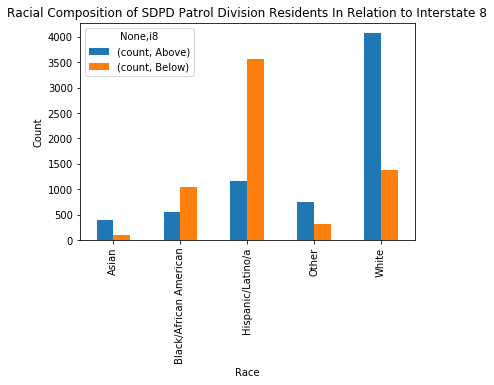

The table below displays the racial and ethnic breakdown of the San Diego Police Department’s nine police divisions. We can see that the highest concentrations of Black residents are found in the Southeastern and Mid-City divisions, whereas the White and Asian/PI populations are consistently at their lowest. Similarly, Hispanic residents tend to live in the Southern, Southeastern, and Mid-City divisions. Socioeconomically, poverty is also concentrated in these neighborhoods. From the data, we can actually see thta census tracts in these divisions are home to many of the San Diego’s poorest residents. Similarly, neighborhoods located above Interstate 8, including those in the Northern, Northeastern, Northwestern, Eastern, and Western divisions, where income levels tend to be higher, are also home to greater percentages of White and API residents.

| region subject_race | count Central | count Eastern | count Mid City | count Northeastern | count Northern | count Northwestern | count Southeastern | count Southern | count Western |
| --- | --- | --- | --- | --- | --- | --- | --- | --- | --- |
| Asian | 0.001904 | 0.004612 | 0.003075 | 0.017205 | 0.002196 | 0.003807 | 0.001318 | 0.001684 | 0.001537 |
| Black/African American | 0.013983 | 0.010835 | 0.029358 | 0.010396 | 0.008785 | 0.002562 | 0.027894 | 0.005271 | 0.008493 |
| Hispanic/Latino/a | 0.038656 | 0.019621 | 0.041218 | 0.018010 | 0.020280 | 0.008127 | 0.037411 | 0.143715 | 0.019401 |
| Other | 0.015448 | 0.010323 | 0.003514 | 0.021524 | 0.010982 | 0.006077 | 0.002489 | 0.001684 | 0.005418 |
| White | 0.050955 | 0.055861 | 0.024746 | 0.069624 | 0.082656 | 0.030603 | 0.005637 | 0.019255 | 0.059448 |

## Moving Beyond SDSU

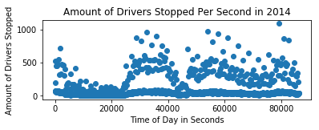

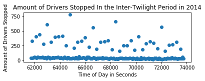

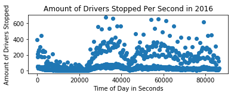

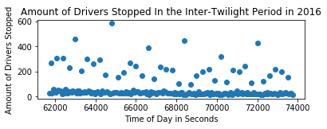

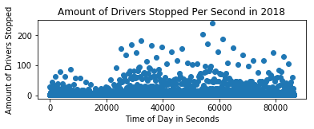

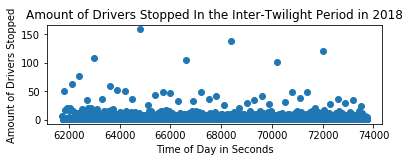

[figure not shown]

[figure not shown]

```
Text(0,0.5,'Mean Rates')
```

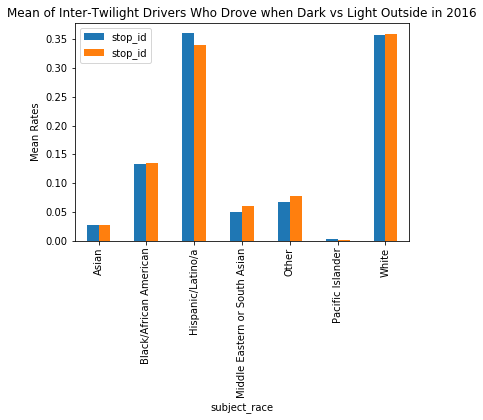

```
Ks_2sampResult(statistic=0.1428571428571429, pvalue=0.9999951796657175)
```

```
Text(0,0.5,'Mean Rates')
```

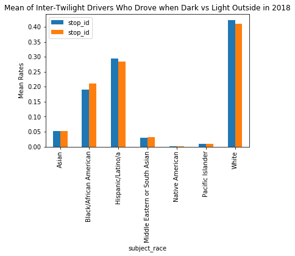

```
Ks_2sampResult(statistic=0.1428571428571429, pvalue=0.9999951796657175)
```

```
Text(0,0.5,'Mean Rates')
```

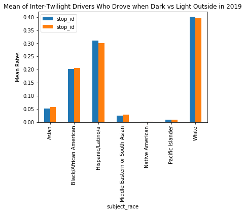

```
Ks_2sampResult(statistic=0.1428571428571429, pvalue=0.9999951796657175)
```

| subject_race | Asian | Black/African American | Hispanic/Latino/a | Pacific Islander | White |
| --- | --- | --- | --- | --- | --- |
| arrested | 0.066037 | 0.111523 | 0.067120 | 0.145593 | 0.073137 |
| contraband_found | 0.021499 | 0.049910 | 0.025194 | 0.047871 | 0.025949 |
| property_seized | 0.008284 | 0.016311 | 0.012128 | 0.022450 | 0.009764 |
| searched | 0.079484 | 0.168851 | 0.107345 | 0.172664 | 0.088670 |
| subject_race | 25955.000000 | 98276.000000 | 211160.000000 | 3029.000000 | 300396.000000 |

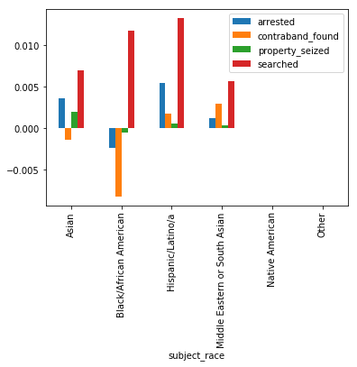